# Final Report

### Classification methods

```r
data1 <- data.frame(X, y)
set.seed(421)
split <- initial_split(data1, prop = 0.8, strata = y)
train <- split %>% training()
test <- split %>% testing()
```

Before constructing the model, to ensure reproducibility, we split the data into training and testing sets by 80%. We set a random seed to ensure reproducibility. Additionally, we ensured that each unique value of ‘y’ was proportionally represented in both sets.

## KNN

```r
knnModel <- train( y ~ ., data = train, method = "knn", trControl = trainControl(method = "cv"), tuneGrid = data.frame(k = c(3,5,7)))
best_model_knn <- knn3(y ~ .,data = train,k = knnModel$bestTune$k)
```

We first constructed a k-nearest neighbors (KNN) model using cross-validation. A grid was employed to tune the selected hyperparameter k, the number of neighbors, within a range from 3 to 7 in our KNN model. We specified “knn” as the method for training.

## KNN Result

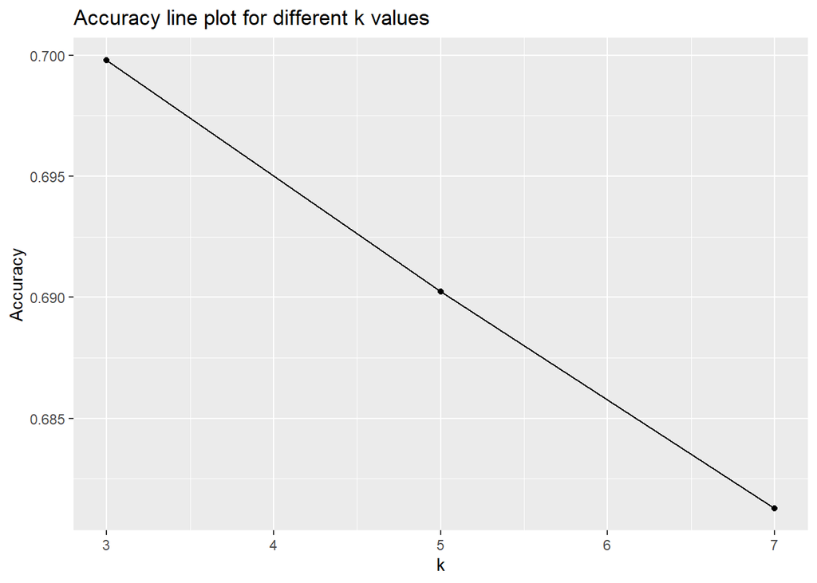

```r
predictions_knn <- predict(best_model_knn, test,type = "class")
cmknn <- confusionMatrix(predictions_knn, test$y)
cm_knn <- as.data.frame(as.table(cmknn$table))
colnames(cm_knn) <- c("Predicted", "True", "Freq")
result_knn <- as.data.frame(knnModel$results)
ggplot(result_knn, aes(x = k, y = Accuracy)) +geom_point() +geom_line() +labs(title = "Accuracy line plot for different k values", x = "k", y = "Accuracy")
```

We evaluated the model performance by examining the confusion matrix and plotting accuracy scores across different values of ‘k’. From the overall statistics by confusionMatrix(), we found that the KNN model achieved an accuracy of 0.70, a precision of 0.69, a recall of 0.68, and an F1 score of 0.68. These results were obtained using the optimal grid value of 3 for k, as illustrated in the accuracy line plot for various k values.